# Visualización en el espacio - EM

Juan Pablo Mosquera Marin - 20221020026 Ana Laura Morcote Chacon - 20221020010 Hana Sofia Pinilla Manrique - 20221020092 Juan David Amaya Patiño - 20221020057

2026-08-28

# 1 Tipos de dato del dataset de crédito

En la exploración de datos, este fue uno de los datasets los cuales se auditó; y el que se usará. En dicha exploración, se notó como todas las columnas pertenecen a la categoría “numeric”; sin embargo el diccionario de datos indica que “SEX”, “EDUCATION”, “MARRIAGE”, de “PAY_0” a “PAY_6” y “default payment next month” son en realidad variables categoricas.

## 1.1 Carga de los datos y corrección de tipos de variable

En este chunk se realizan dos tareas principales:

1. **Carga de los datos**: se lee el archivo `datos_credit.csv` (ubicado en la carpeta `DATASET` del proyecto) y se guarda en el objeto `datos_credit`. A partir de él se crea una copia de trabajo llamada `datos_credit_visu`, que será la que se use en todas las visualizaciones del documento.
2. **Corrección de tipo de dato**: como se explicó arriba, aunque R interpreta todas las columnas del dataset como numéricas, varias de ellas en realidad representan **categorías codificadas con números** y no cantidades continuas. Por eso se convierten a `factor` las siguientes variables:
   - `SEX`: sexo del cliente (codificado numéricamente).
   - `EDUCATION`: nivel educativo (codificado numéricamente).
   - `MARRIAGE`: estado civil (codificado numéricamente).
   - `default payment next month`: variable de respuesta que indica si el cliente incurrió en impago al mes siguiente (0/1).
   - `PAY_0`, `PAY_2`, `PAY_3`, `PAY_4`, `PAY_5`, `PAY_6`: estado de pago del cliente en cada uno de los meses anteriores (codificado con números que representan categorías de retraso, no cantidades).

Esta corrección es necesaria porque, si estas variables se dejan como numéricas, cualquier análisis o gráfico posterior las trataría incorrectamente como cantidades continuas (por ejemplo, calculando promedios o desviaciones estándar sobre categorías), lo cual no tiene sentido estadístico ni interpretativo.

```r
datos_credit <- read_csv(here("DATASET", "datos_credit.csv"))
datos_credit_visu <- datos_credit %>%
  select_all()

datos_credit_visu$SEX <- as.factor(datos_credit_visu$SEX)
datos_credit_visu$EDUCATION <- as.factor(datos_credit_visu$EDUCATION)
datos_credit_visu$MARRIAGE <- as.factor(datos_credit_visu$MARRIAGE)
datos_credit_visu$`default payment next month` <- as.factor(datos_credit_visu$`default payment next month`)
datos_credit_visu$PAY_0 <- as.factor(datos_credit_visu$PAY_0)
datos_credit_visu$PAY_2 <- as.factor(datos_credit_visu$PAY_2)
datos_credit_visu$PAY_3 <- as.factor(datos_credit_visu$PAY_3)
datos_credit_visu$PAY_4 <- as.factor(datos_credit_visu$PAY_4)
datos_credit_visu$PAY_5 <- as.factor(datos_credit_visu$PAY_5)
datos_credit_visu$PAY_6 <- as.factor(datos_credit_visu$PAY_6)
```

#Resumen de los datos tras la transformación a categorica de ciertas columnas

```r
#resumen
summary(datos_credit_visu)
```

```
##    LIMIT_BAL       SEX       EDUCATION MARRIAGE       AGE
##  Min.   :  10000   1:11888   1:10585   1:13659   Min.   :21.00
##  1st Qu.:  50000   2:18112   2:14030   2:15964   1st Qu.:28.00
##  Median : 140000             3: 4917   3:  377   Median :34.00
##  Mean   : 167484             4:  468             Mean   :35.49
##  3rd Qu.: 240000                                 3rd Qu.:41.00
##  Max.   :1000000                                 Max.   :79.00
##
##      PAY_0           PAY_2           PAY_3           PAY_4
##  0      :14737   0      :15730   0      :15764   0      :16455
##  -1     : 5686   -1     : 6050   -1     : 5938   -1     : 5687
##  1      : 3688   2      : 3927   -2     : 4085   -2     : 4348
##  -2     : 2759   -2     : 3782   2      : 3819   2      : 3159
##  2      : 2667   3      :  326   3      :  240   3      :  180
##  3      :  322   4      :   99   4      :   76   4      :   69
##  (Other):  141   (Other):   86   (Other):   78   (Other):  102
##      PAY_5           PAY_6         BILL_AMT1         BILL_AMT2
##  0      :16947   0      :16286   Min.   :-165580   Min.   :-69777
##  -1     : 5539   -1     : 5740   1st Qu.:   3559   1st Qu.:  2985
##  -2     : 4546   -2     : 4895   Median :  22382   Median : 21200
##  2      : 2626   2      : 2766   Mean   :  51223   Mean   : 49179
##  3      :  178   3      :  184   3rd Qu.:  67091   3rd Qu.: 64006
##  4      :   84   4      :   49   Max.   : 964511   Max.   :983931
##  (Other):   80   (Other):   80
##    BILL_AMT3         BILL_AMT4         BILL_AMT5        BILL_AMT6
##  Min.   :-157264   Min.   :-170000   Min.   :-81334   Min.   :-339603
##  1st Qu.:   2666   1st Qu.:   2327   1st Qu.:  1763   1st Qu.:   1256
##  Median :  20089   Median :  19052   Median : 18105   Median :  17071
##  Mean   :  47013   Mean   :  43263   Mean   : 40311   Mean   :  38872
##  3rd Qu.:  60165   3rd Qu.:  54506   3rd Qu.: 50191   3rd Qu.:  49198
##  Max.   :1664089   Max.   : 891586   Max.   :927171   Max.   : 961664
##
##     PAY_AMT1         PAY_AMT2          PAY_AMT3         PAY_AMT4
##  Min.   :     0   Min.   :      0   Min.   :     0   Min.   :     0
##  1st Qu.:  1000   1st Qu.:    833   1st Qu.:   390   1st Qu.:   296
##  Median :  2100   Median :   2009   Median :  1800   Median :  1500
##  Mean   :  5664   Mean   :   5921   Mean   :  5226   Mean   :  4826
##  3rd Qu.:  5006   3rd Qu.:   5000   3rd Qu.:  4505   3rd Qu.:  4013
##  Max.   :873552   Max.   :1684259   Max.   :896040   Max.   :621000
##
##     PAY_AMT5           PAY_AMT6        default payment next month
##  Min.   :     0.0   Min.   :     0.0   0:23364
##  1st Qu.:   252.5   1st Qu.:   117.8   1: 6636
##  Median :  1500.0   Median :  1500.0
##  Mean   :  4799.4   Mean   :  5215.5
##  3rd Qu.:  4031.5   3rd Qu.:  4000.0
##  Max.   :426529.0   Max.   :528666.0
##
```

# 2 Diagramas de Caja y Bigotes

## 2.1 Comparación de todas las variables númericas

Se comparan simultáneamente todas las variables **verdaderamente numéricas** del dataset (montos de crédito, edad, montos de estado de cuenta y montos pagados), primero en su escala original y luego estandarizadas, para poder compararlas entre sí sin que las diferencias de magnitud (por ejemplo, edad en años vs. montos en miles de dólares) distorsionen la lectura visual.

### 2.1.1 Sin estandarizar

Este chunk genera cinco diagramas de caja y bigotes con las variables numéricas **en su escala original** (sin transformar estadísticamente), solo dividiendo los montos monetarios entre 10.000 para que los ejes sean más legibles:

- `LIMIT_BAL` (monto de crédito otorgado) sola.
- `AGE` (edad) sola.
- `BILL_AMT1` a `BILL_AMT6` (montos del estado de cuenta de los últimos 6 meses) comparadas entre sí.
- `PAY_AMT1` a `PAY_AMT6` (montos efectivamente pagados en los últimos 6 meses) comparadas entre sí.
- Todas las anteriores juntas (`LIMIT_BAL`, `AGE`, `BILL_AMT1:6`, `PAY_AMT1:6`) en un solo gráfico comparativo.

No se cruza ninguna variable categórica en este chunk; el objetivo es únicamente observar la distribución y dispersión de cada variable numérica y detectar posibles valores atípicos.

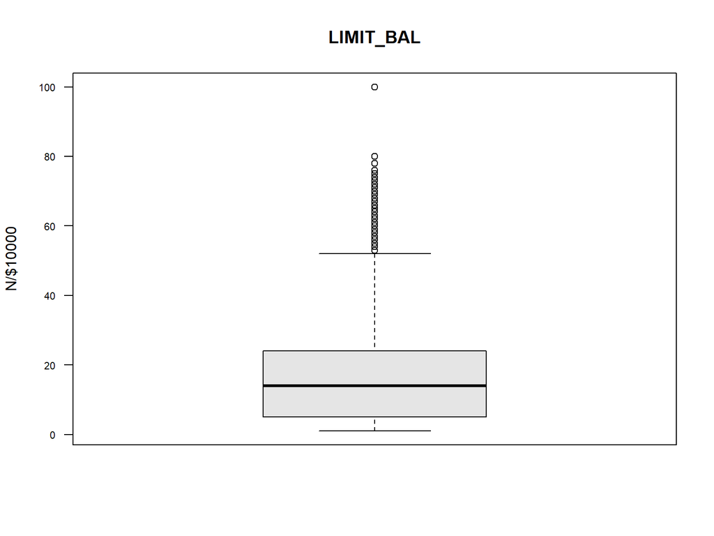

```r
#solo de limit_bal
boxplot(datos_credit_visu[, 1:1]/10000, las = 2, cex.axis = 0.7,
        main = "LIMIT_BAL",
        ylab = "N/$10000", col = "grey90")
```

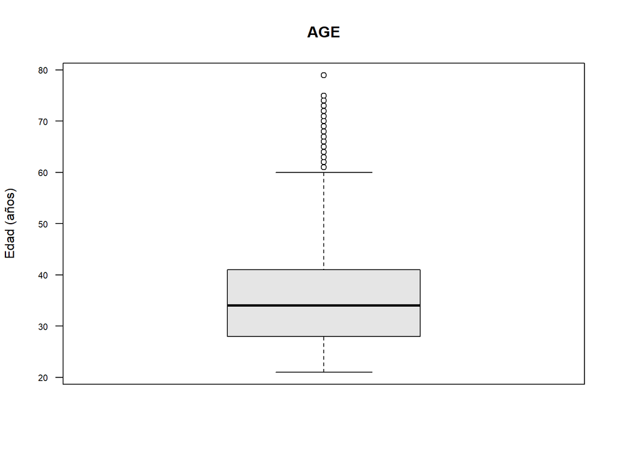

```r
#solo de age
boxplot(datos_credit_visu[, 5:5], las = 2, cex.axis = 0.7,
        main = "AGE",
        ylab = "Edad (años)", col = "grey90")
```

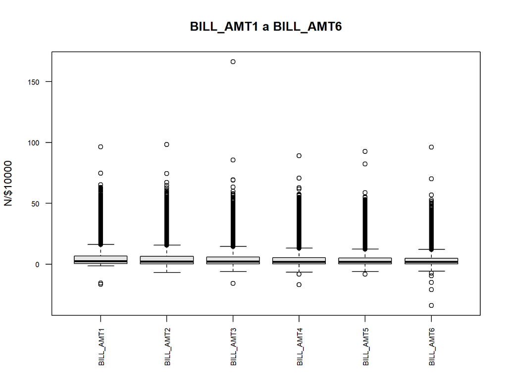

```r
#comparación de los de bill_amt
boxplot(datos_credit_visu[, 12:17]/10000, las = 2, cex.axis = 0.7,
        main = "BILL_AMT1 a BILL_AMT6",
        ylab = "N/$10000", col = "grey90")
```

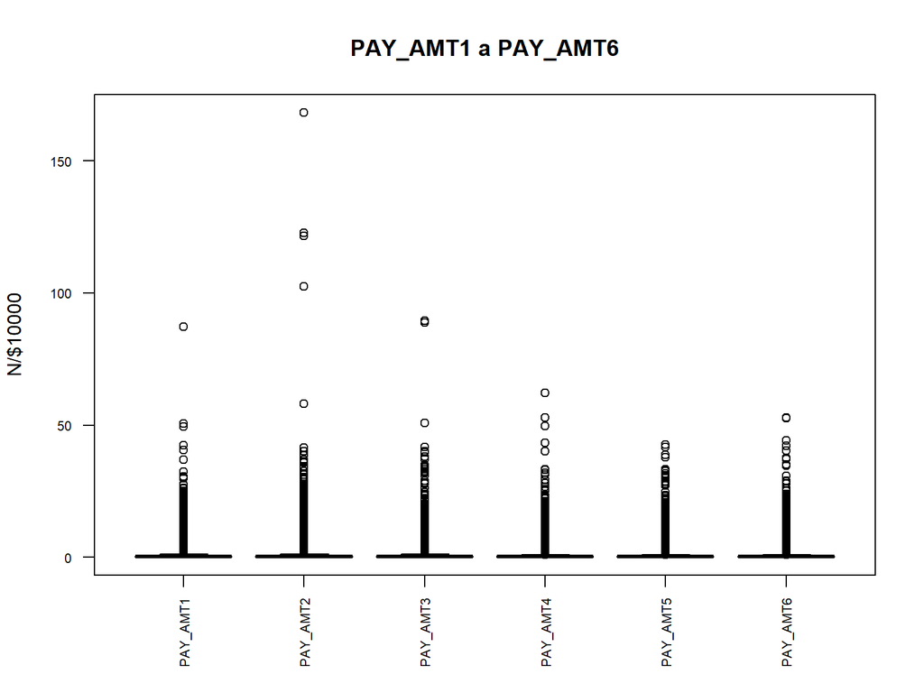

```r
#comparación de los de pay_amt
boxplot(datos_credit_visu[, 18:23]/10000, las = 2, cex.axis = 0.7,
        main = "PAY_AMT1 a PAY_AMT6",
        ylab = "N/$10000", col = "grey90")
```

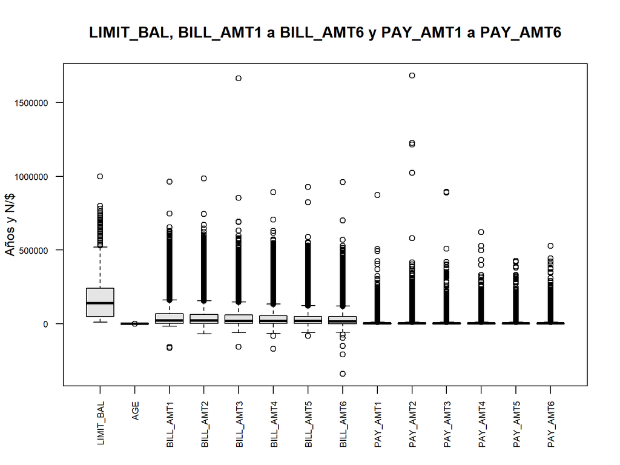

```r
#comparación de todos
boxplot(datos_credit_visu[, c(1, c(5, 12:23))], las = 2, cex.axis = 0.7,
        main = "LIMIT_BAL, BILL_AMT1 a BILL_AMT6 y PAY_AMT1 a PAY_AMT6",
        ylab = "Años y N/$", col = "grey90")
```

Aunque sea algo dificil apreciar detalles en estos boxplot, se pueden ver ciertos detalles interesantes. El primero de ellos es que **la media y la mediana son cercanas entre sí**; sin embargo, comparando con la información del **summary()**,los únicos casos en los que son cercanas es en LIMIT_BAL (relativamente) y AGE, y se ahondará en ello más adelante. Lo segundo es que **los campos BILL_AMT tienen comportamientos muy similares entre sí**; salvo un par de datos anomalos, entre otros detalles, el diagrama muestra que estas variables se comportan muy similar. Lo tercero es que en las variables **PAY_ATM, la media, la mediana, 1er y 3er se encuentran muy próximos entre sí y muy cerca del origen: la mayoría de los clientes realizó pagos de magnitud reducida en relación con el rango total de la variable**. Para finalizar, tomando el gráfico donde se comparan todas las variables juntas sin estandarizar y sin ´división entre 10000 aplicada, LIMIT_BAL es la única variable medianamente legible. AGE, por su parte, queda reducida a una línea plana sobre el eje. Del boxplot individual de estas últimas dos variables se pueden sacar ciertos detalles: 1. La caja de LIMIT_BAL no es simétrica respecto de la mediana: la distancia entre Q1 y la mediana es menor que la distancia entre la mediana y Q3, y el bigote superior es considerablemente más extenso que el inferior. Esto configura un sesgo a la derecha. 2. Al igual que en el caso de LIMIT_BAL, la distribución de AGE muestra un sesgo a la derecha, aunque de menor magnitud: la mediana se sitúa levemente por debajo del centro de la caja y el bigote superior es más largo que el inferior. *Cabe aclarar que todas estas variables a excepción de AGE manejan las mismas unidades base (NT/$), por lo que se esperaría que el output fuera casi identico.*

### 2.1.2 Estandarizadas

Este chunk repite exactamente las mismas cinco comparaciones del chunk anterior, pero aplicando la función `scale()` a cada conjunto de variables. `scale()` **estandariza** los datos, es decir, les resta su media y los divide entre su desviación estándar, dejándolos expresados en unidades de desviación estándar (con media 0). Esta transformación es necesaria porque variables como `AGE` (en años) y `BILL_AMT` (en miles de pesos taiwaneses) tienen escalas y unidades completamente distintas; al estandarizarlas, se pueden comparar visualmente su dispersión y valores atípicos en una misma escala común. La línea horizontal en 0 (`abline(h = 0, lty = 3)`) marca la media de cada variable tras la estandarización.

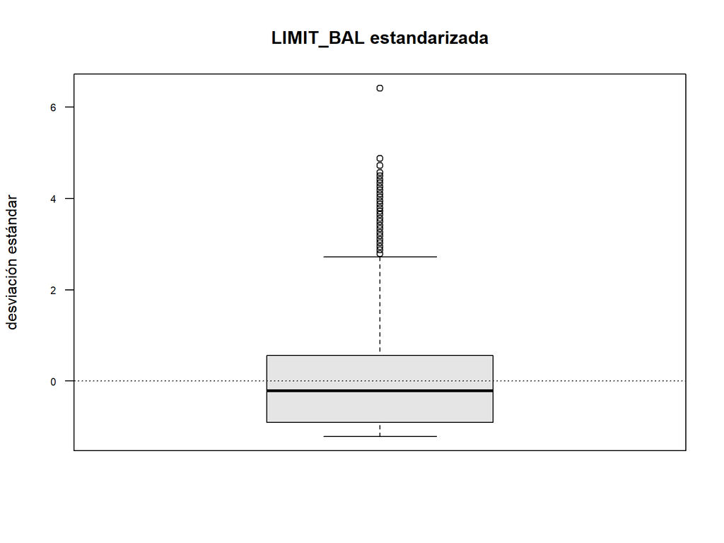

```r
#solo de limit_bal
boxplot(scale(datos_credit_visu[, 1:1]), las = 2, cex.axis = 0.7,
        main = "LIMIT_BAL estandarizada",
        ylab = "desviación estándar", col = "grey90")
abline(h = 0, lty = 3)
```

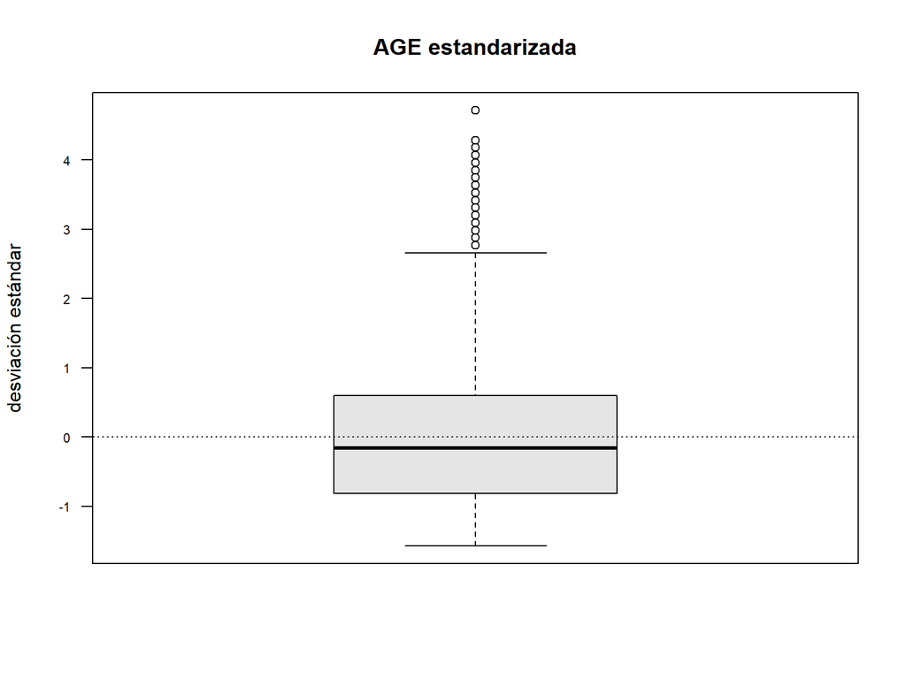

```r
#solo de age
boxplot(scale(datos_credit_visu[, 5:5]), las = 2, cex.axis = 0.7,
        main = "AGE estandarizada",
        ylab = "desviación estándar", col = "grey90")
abline(h = 0, lty = 3)
```

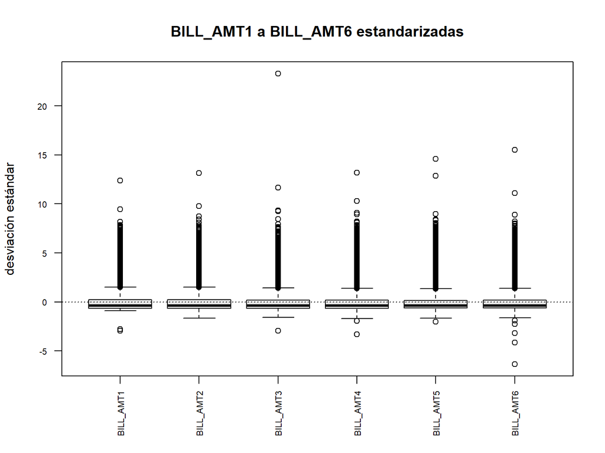

```r
#comparación de los de bill_amt
boxplot(scale(datos_credit_visu[, 12:17]), las = 2, cex.axis = 0.7,
        main = "BILL_AMT1 a BILL_AMT6 estandarizadas",
        ylab = "desviación estándar", col = "grey90")
abline(h = 0, lty = 3)
```

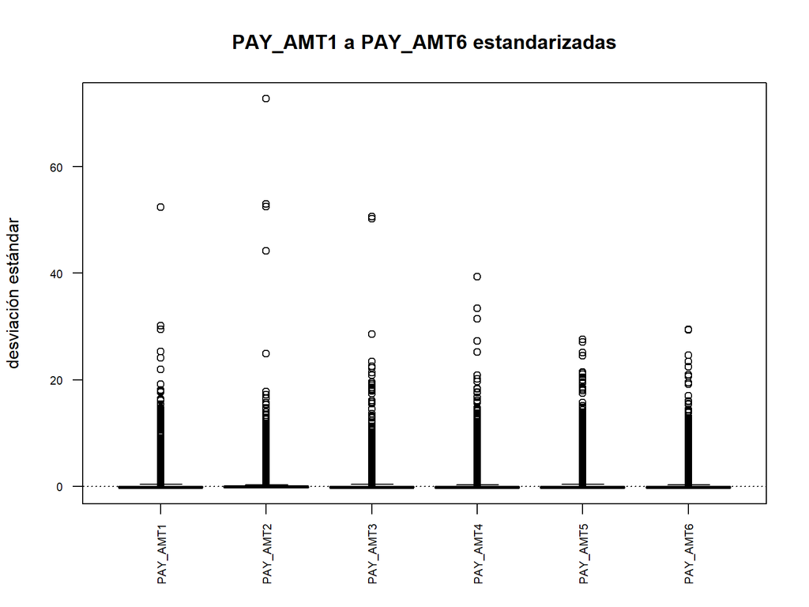

```r
#comparación de los de pay_amt
boxplot(scale(datos_credit_visu[, 18:23]), las = 2, cex.axis = 0.7,
        main = "PAY_AMT1 a PAY_AMT6 estandarizadas",
        ylab = "desviación estándar", col = "grey90")
abline(h = 0, lty = 3)
```

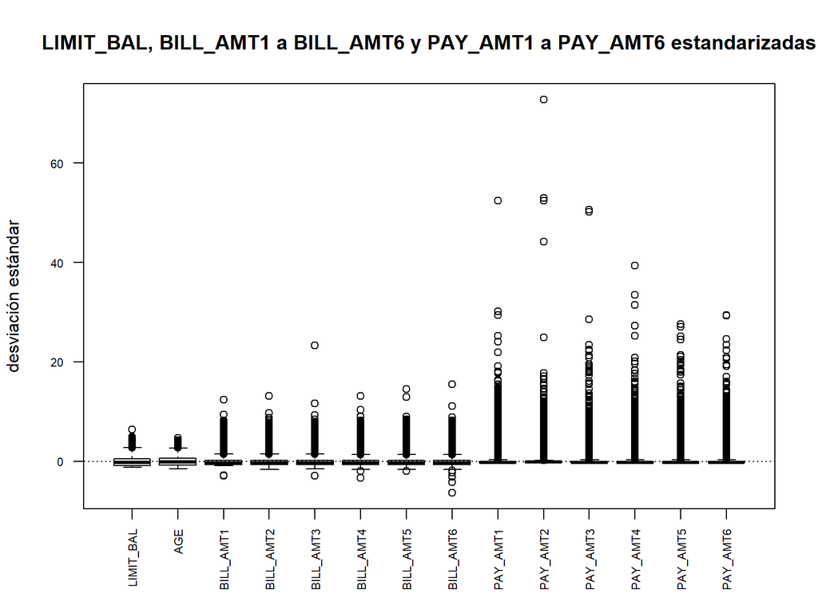

```r
#comparación de todos
boxplot(scale(datos_credit_visu[, c(1, c(5, 12:23))]), las = 2, cex.axis = 0.7,
        main = "LIMIT_BAL, BILL_AMT1 a BILL_AMT6 y PAY_AMT1 a PAY_AMT6 estandarizadas",
        ylab = "desviación estándar", col = "grey90")
abline(h = 0, lty = 3)
```

`LIMIT_BAL` y `AGE` son, en términos relativos, las variables mejor comportadas del conjunto: su dispersión total se explica bastante bien por su propia desviación estándar.

Las seis `PAY_AMT` son el caso extremo y es aquí donde la estandarización revela algo que el gráfico sin transformar escondía. Sus cajas están literalmente colapsadas sobre la línea de cero, es decir, el 50 % central de las observaciones cabe en un intervalo mucho menor que una desviación estándar, mientras que los atípicos forman columnas verticales densas que llegan a 20 y 30 desviaciones y con puntos aislados. Un valor a 73 desviaciones de la media es un dato brutalmente extremo: significa que la desviación estándar de esa variable está siendo determinada casi por completo por un puñado de observaciones. También se nota que no hay nada por debajo de cero: como los pagos no pueden ser negativos y la media es pequeña, el piso de la distribución queda apenas unas décimas de desviación por debajo de la línea, y eso produce la franja recta que se ve en la base de las seis.

## 2.2 De “SEX”

En esta sección se cruza la variable categórica `SEX` (sexo del cliente, convertida a factor en el chunk de preparación de datos) contra cada una de las variables numéricas relevantes, para observar si existen diferencias en su distribución según el sexo del cliente.

El diagrama de caja y bigotes se cruza `LIMIT_BAL` (monto de crédito otorgado, dividido entre 10.000 para legibilidad) contra `SEX`, para comparar si el monto de crédito otorgado difiere entre hombres y mujeres.

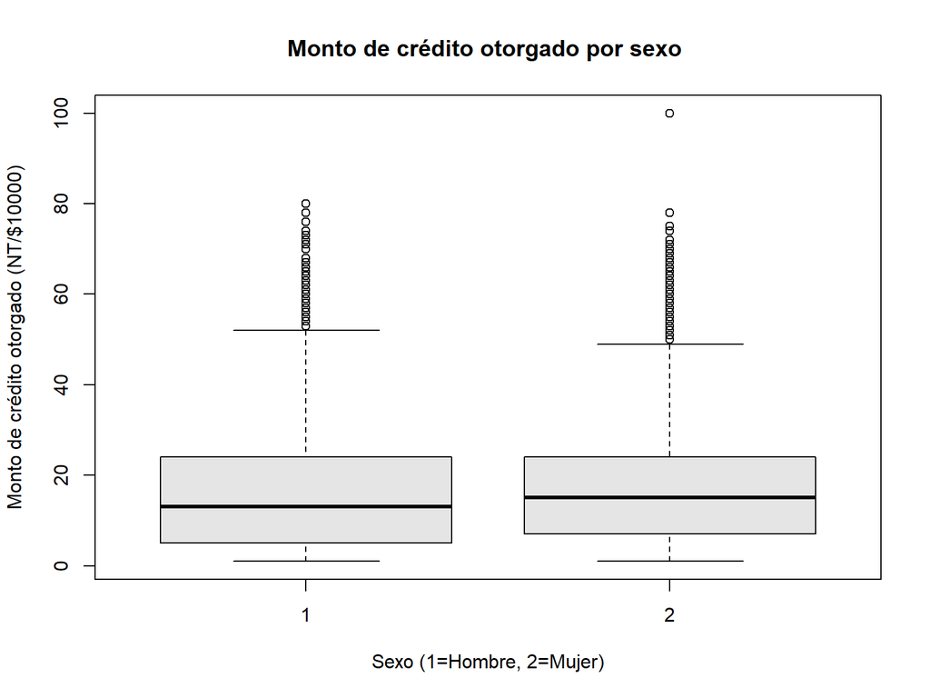

```r
boxplot(LIMIT_BAL/10000 ~ SEX, data = datos_credit_visu,
        main = "Monto de crédito otorgado por sexo ",
        xlab = "Sexo (1=Hombre, 2=Mujer)", ylab = "Monto de crédito otorgado (NT/$10000)",
        col = "grey90")
```

Lo primero que muestra el gráfico es que las dos distribuciones son muy parecidas entre sí. Ambas cajas ocupan prácticamente la misma franja del eje, ambos grupos parten de un mínimo cercano a 1 (NT$10.000) y los dos presentan la misma forma general: sesgo hacía la derecha, con la mediana desplazada hacia el borde inferior de la caja y una cola larga de valores atípicos por arriba. Es decir, el patrón de la variable `LIMIT_BAL` que ya se había descrito para el conjunto completo se reproduce casi idéntico dentro de cada categoría de sexo.

Las diferencias que sí se aprecian son de posición y pequeñas. La mediana del grupo 1 (hombres) se ubica alrededor de 13 unidades de NT/$10.000, mientras que la del grupo 2 (mujeres) está cerca de 15. El primer cuartil también difiere: aproximadamente 5 en hombres frente a 7 en mujeres. El tercer cuartil, en cambio, es casi coincidente en ambos grupos, cerca de 24-25. El resultado es que el rango intercuartílico de las mujeres es levemente más estrecho (unas 18 unidades frente a 19-20 en hombres) y está desplazado un poco hacia arriba: **la mitad central de las clientas recibió cupos algo mayores que la mitad central de los clientes.**

En los extremos la relación se invierte de forma leve. El bigote superior de los hombres alcanza aproximadamente 52 y el de las mujeres 49, y el máximo del conjunto de atípicos ordinarios está cerca de 80 en hombres y 78 en mujeres. Sin embargo, el punto extremo aislado en 100 (el cupo de NT$1.000.000, máximo de todo el conjunto de datos) pertenece al grupo de las mujeres. Ambos grupos tienen nubes densas de atípicos superiores de extensión comparable, y ninguno registra atípicos inferiores.

La lectura de conjunto es que el solapamiento entre las dos distribuciones es casi total: la diferencia entre las medianas (unas 2 unidades, es decir NT$20.000) es muy pequeña frente al rango intercuartílico de cada grupo, que ronda las 19 unidades. Visualmente, el sexo no aparece como un factor que separe la distribución del cupo otorgado; lo que el gráfico muestra es un desplazamiento marginal hacia arriba en el grupo femenino, sobre todo en la mitad inferior de la distribución. *Hay que tener en cuenta que los tamaños de los dos grupos no son iguales en este conjunto de datos y el boxplot no los refleja.*

A continuación, se cruza `AGE` (edad) contra `SEX`, para observar si la distribución de edades varía entre hombres y mujeres.

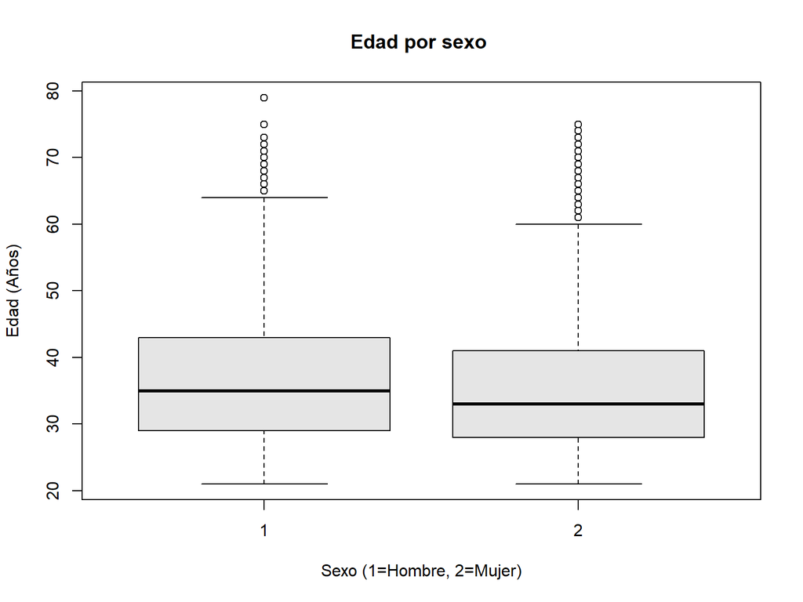

```r
boxplot(AGE ~ SEX, data = datos_credit_visu,
        main = "Edad por sexo ",
        xlab = "Sexo (1=Hombre, 2=Mujer)", ylab = "Edad (Años)",
        col = "grey90")
```

El solapamiento entre ambas distribuciones es casi completo y la diferencia de aproximadamente dos años entre las medianas es muy pequeña frente a un rango intercuartílico de unos trece o catorce años. Lo que el gráfico permite afirmar de manera descriptiva es que los clientes hombres de este conjunto tienden a ser marginalmente mayores que las clientas, y que la edad máxima registrada corresponde al grupo masculino, pero no que el sexo separe la distribución etaria de forma sustantiva. Vale la pena recordar, como en el gráfico anterior, que el diagrama de caja no informa sobre el tamaño de cada grupo, lo cual conviene reportar aparte si estas comparaciones se van a incluir en el informe.

Prosiguiendo, este chunk cruza cada una de las seis variables `BILL_AMT1` a `BILL_AMT6` (montos del estado de cuenta de septiembre a abril de 2005, divididos entre 10.000) contra `SEX`, generando un boxplot por cada mes para comparar el monto del estado de cuenta entre hombres y mujeres mes a mes.

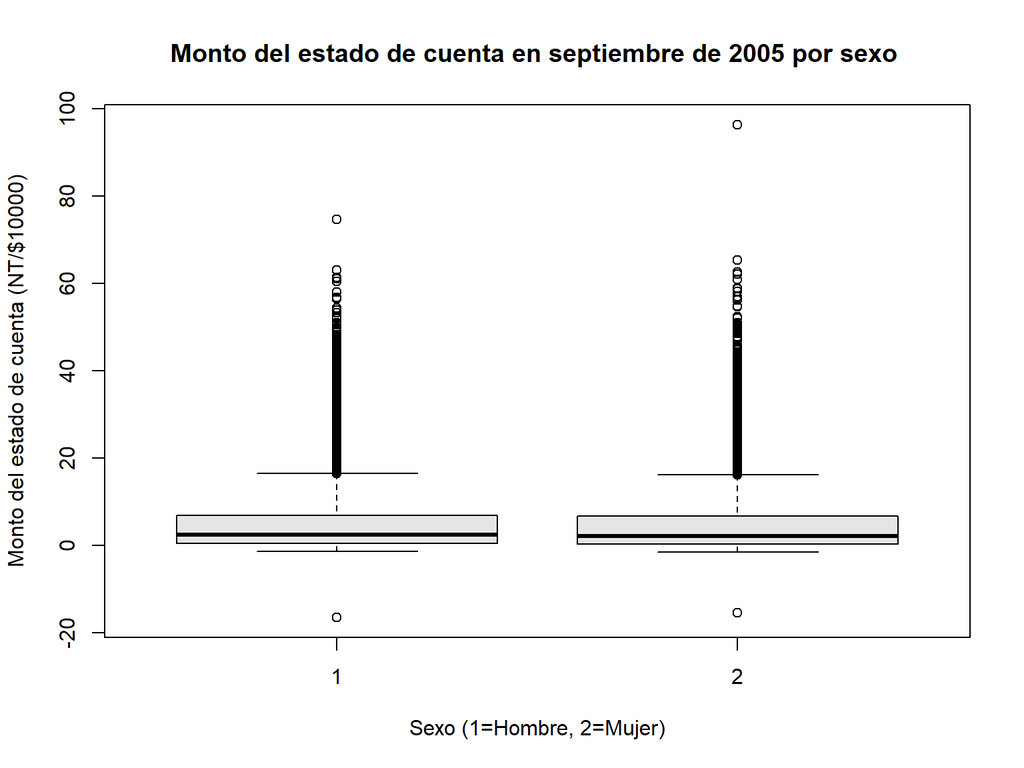

```r
boxplot(BILL_AMT1/10000 ~ SEX, data = datos_credit_visu,
        main = "Monto del estado de cuenta en septiembre de 2005 por sexo ",
        xlab = "Sexo (1=Hombre, 2=Mujer)", ylab = "Monto del estado de cuenta (NT/$10000)",
        col = "grey90")
```

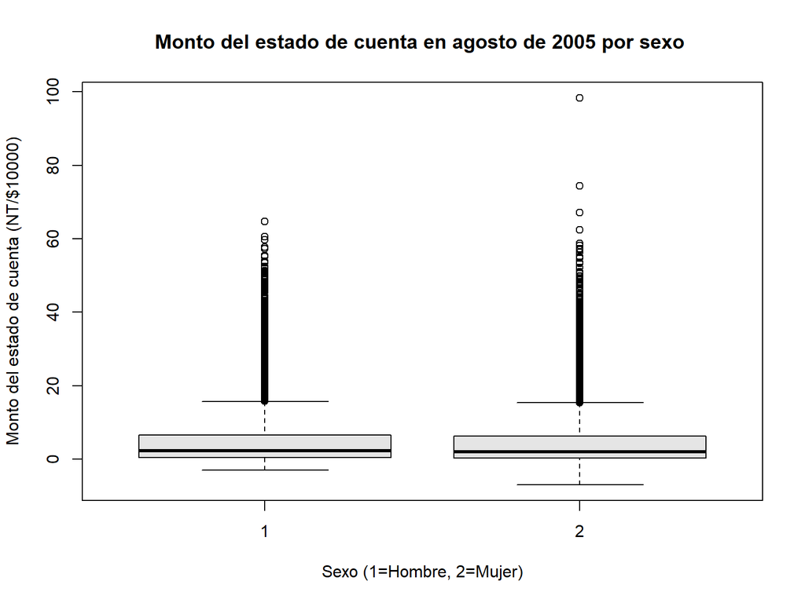

```r
boxplot(BILL_AMT2/10000 ~ SEX, data = datos_credit_visu,
        main = "Monto del estado de cuenta en agosto de 2005 por sexo ",
        xlab = "Sexo (1=Hombre, 2=Mujer)", ylab = "Monto del estado de cuenta (NT/$10000)",
        col = "grey90")
```

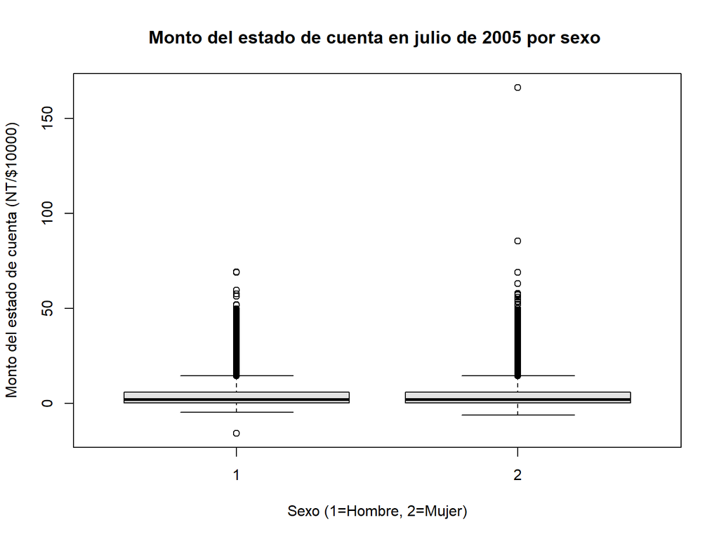

```r
boxplot(BILL_AMT3/10000 ~ SEX, data = datos_credit_visu,
        main = "Monto del estado de cuenta en julio de 2005 por sexo ",
        xlab = "Sexo (1=Hombre, 2=Mujer)", ylab = "Monto del estado de cuenta (NT/$10000)",
        col = "grey90")
```

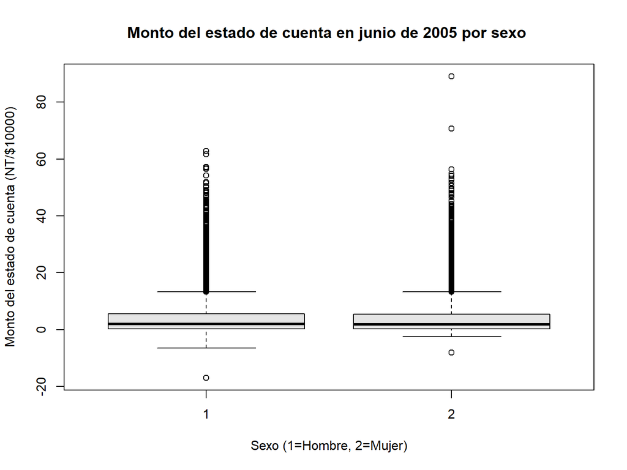

```r
boxplot(BILL_AMT4/10000 ~ SEX, data = datos_credit_visu,
        main = "Monto del estado de cuenta en junio de 2005 por sexo ",
        xlab = "Sexo (1=Hombre, 2=Mujer)", ylab = "Monto del estado de cuenta (NT/$10000)",
        col = "grey90")
```

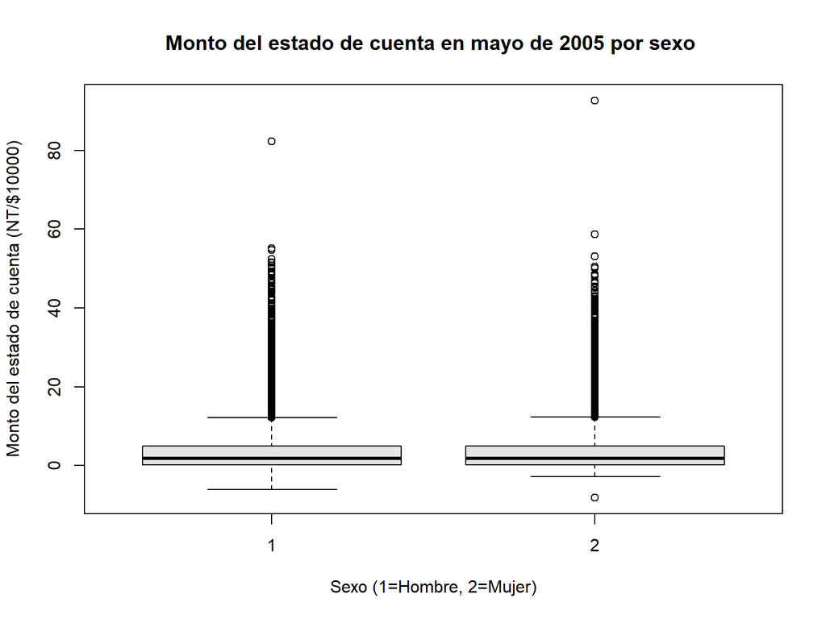

```r
boxplot(BILL_AMT5/10000 ~ SEX, data = datos_credit_visu,
        main = "Monto del estado de cuenta en mayo de 2005 por sexo ",
        xlab = "Sexo (1=Hombre, 2=Mujer)", ylab = "Monto del estado de cuenta (NT/$10000)",
        col = "grey90")
```

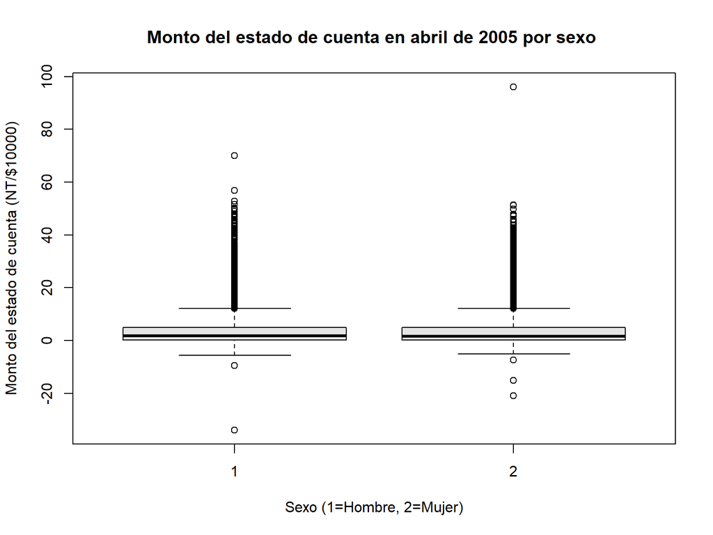

```r
boxplot(BILL_AMT6/10000 ~ SEX, data = datos_credit_visu,
        main = "Monto del estado de cuenta en abril de 2005 por sexo ",
        xlab = "Sexo (1=Hombre, 2=Mujer)", ylab = "Monto del estado de cuenta (NT/$10000)",
        col = "grey90")
```

Los seis meses muestran lo mismo: hombres y mujeres tienen distribuciones prácticamente idénticas. Medianas cercanas a 2 unidades de NT/$10.000 en ambos grupos, cajas que van de 0 a 6 aproximadamente, y bigotes superiores que coinciden entre los dos sexos en cada mes. El sexo no separa esta variable.

Ojo con las escalas: cada panel tiene un eje vertical distinto (julio llega a 150, junio a 80), así que comparar meses a simple vista engaña.

En los seis casos la forma es la misma: asimetría positiva fuerte, mediana pegada al borde inferior de la caja, y una columna densa y continua de atípicos hasta 50-60 unidades.

El máximo siempre está en el grupo 2. Julio es el caso extremo: 166 en mujeres frente a 70 en hombres. Pero las mujeres son el grupo más numeroso del dataset, y a más observaciones, más probabilidad de extremos; el boxplot no muestra ese tamaño, así que el patrón puede ser solo eso.

Hay valores negativos en ambos grupos todos los meses. El más profundo es aproximadamente -34 en hombres en abril.

Ahora, este chunk cruza las seis variables `PAY_AMT1` a `PAY_AMT6` (montos efectivamente pagados por el cliente de septiembre a abril de 2005, divididos entre 10.000) contra `SEX`, para comparar cuánto pagaron efectivamente hombres y mujeres cada mes.

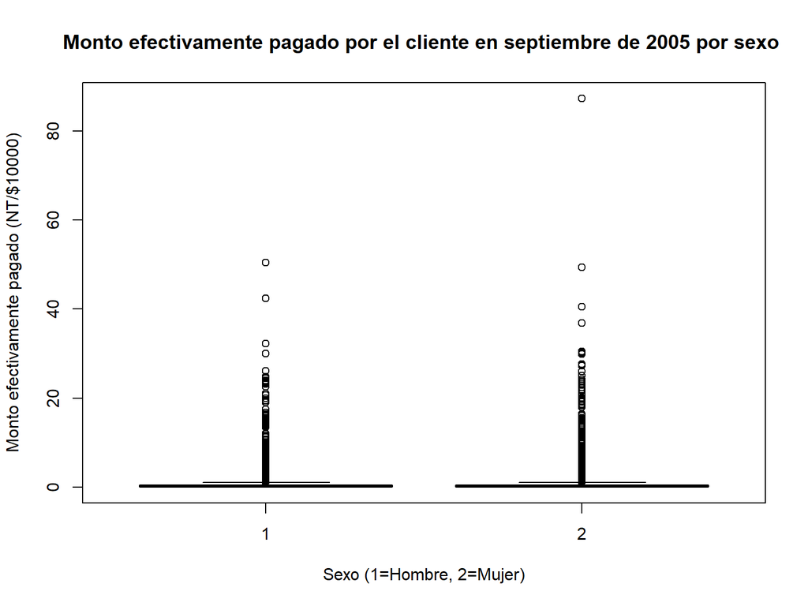

```r
boxplot(PAY_AMT1/10000 ~ SEX, data = datos_credit_visu,
        main = "Monto efectivamente pagado por el cliente en septiembre de 2005 por sexo ",
        xlab = "Sexo (1=Hombre, 2=Mujer)", ylab = "Monto efectivamente pagado (NT/$10000)",
        col = "grey90")
```

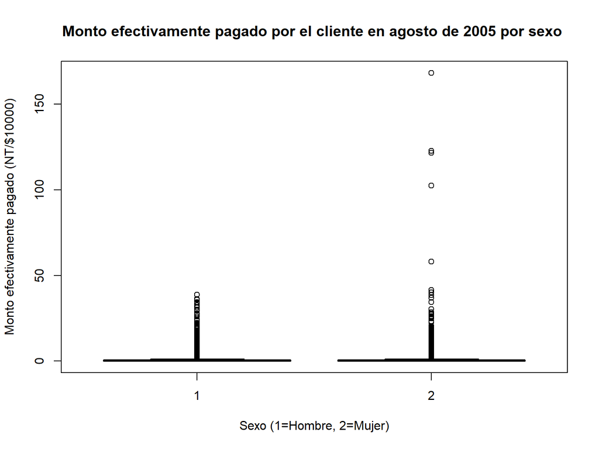

```r
boxplot(PAY_AMT2/10000 ~ SEX, data = datos_credit_visu,
        main = "Monto efectivamente pagado por el cliente en agosto de 2005 por sexo ",
        xlab = "Sexo (1=Hombre, 2=Mujer)", ylab = "Monto efectivamente pagado (NT/$10000)",
        col = "grey90")
```

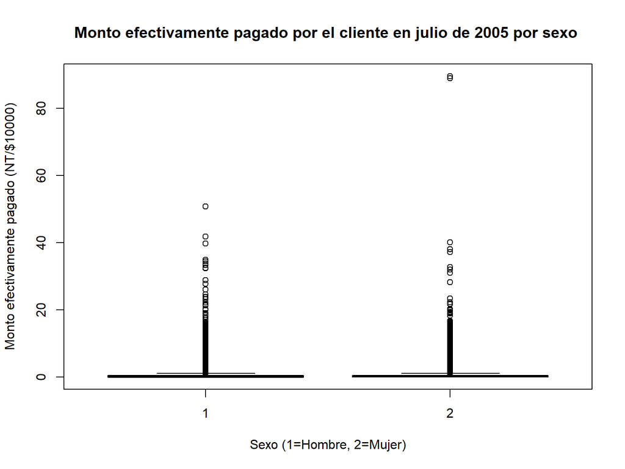

```r
boxplot(PAY_AMT3/10000 ~ SEX, data = datos_credit_visu,
        main = "Monto efectivamente pagado por el cliente en julio de 2005 por sexo ",
        xlab = "Sexo (1=Hombre, 2=Mujer)", ylab = "Monto efectivamente pagado (NT/$10000)",
        col = "grey90")
```

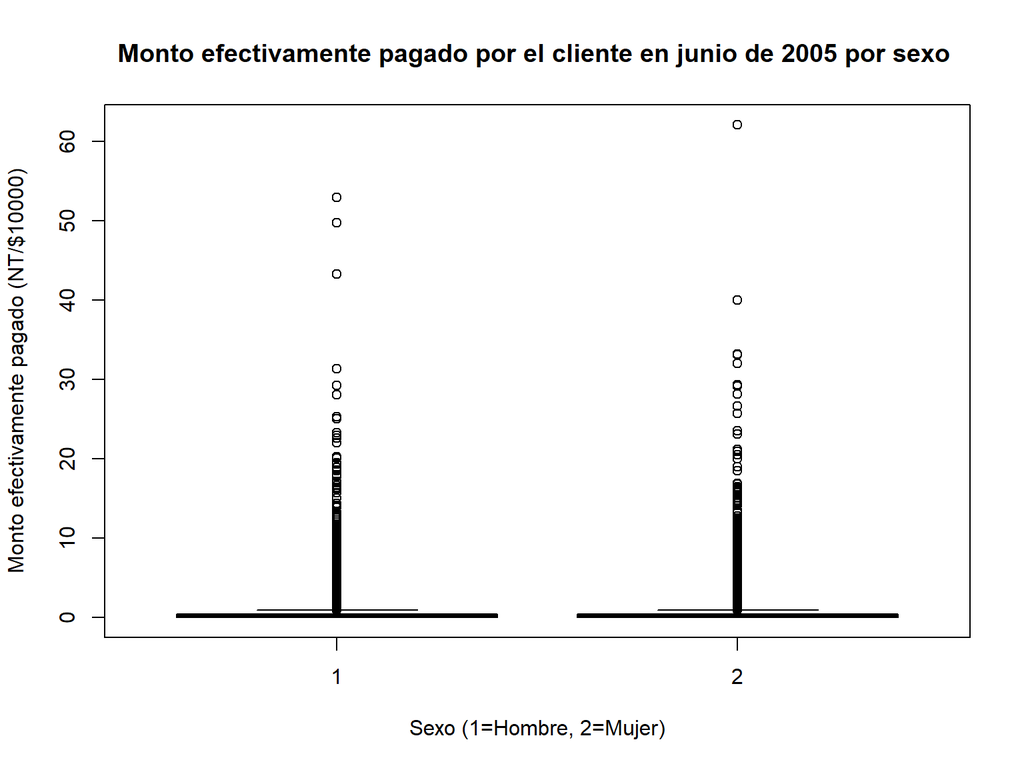

```r
boxplot(PAY_AMT4/10000 ~ SEX, data = datos_credit_visu,
        main = "Monto efectivamente pagado por el cliente en junio de 2005 por sexo ",
        xlab = "Sexo (1=Hombre, 2=Mujer)", ylab = "Monto efectivamente pagado (NT/$10000)",
        col = "grey90")
```

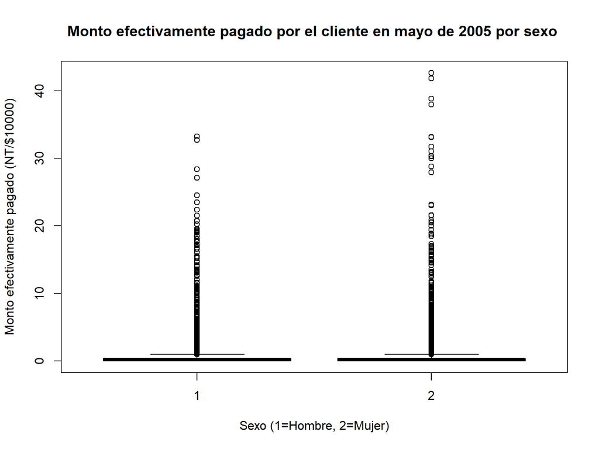

```r
boxplot(PAY_AMT5/10000 ~ SEX, data = datos_credit_visu,
        main = "Monto efectivamente pagado por el cliente en mayo de 2005 por sexo ",
        xlab = "Sexo (1=Hombre, 2=Mujer)", ylab = "Monto efectivamente pagado (NT/$10000)",
        col = "grey90")
```

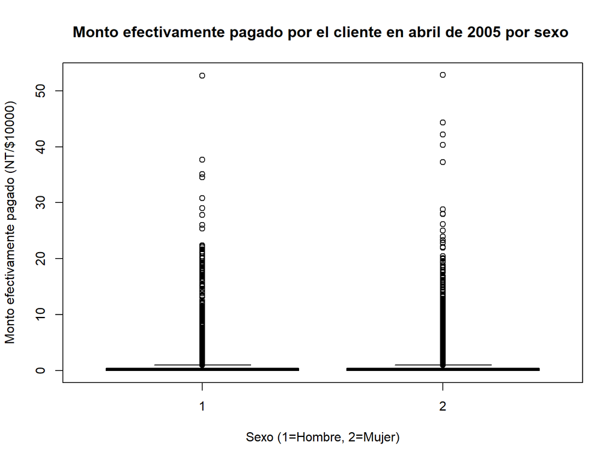

```r
boxplot(PAY_AMT6/10000 ~ SEX, data = datos_credit_visu,
        main = "Monto efectivamente pagado por el cliente en abril de 2005 por sexo ",
        xlab = "Sexo (1=Hombre, 2=Mujer)", ylab = "Monto efectivamente pagado (NT/$10000)",
        col = "grey90")
```

Las cajas están colapsadas sobre cero en los dos grupos y en los seis meses. No se distingue mediana ni cuartiles: todo el rango intercuartílico cabe en menos de 1 unidad de NT/$10.000. El bigote superior llega a cerca de 1 unidad (NT$10.000). Sexo y mes son irrelevantes para esto: las doce cajas se ven iguales.

Toda la información está en los atípicos. Forman una columna vertical densa desde cero hasta unas 20-25 unidades, y encima puntos sueltos.

Cinco de seis meses tienen el máximo en mujeres. Agosto es el caso extremo: 168 frente a 40, con cuatro puntos aislados en el grupo 2 (168, 122, 102, 58) que no tienen contraparte en hombres.

Ojo con las escalas: cada panel tiene eje propio (agosto llega a 150, mayo a 40). La columna de atípicos de mayo parece más alta que la de agosto solo por eso.

Comparado con BILL_AMT: allí las cajas eran visibles y había negativos. Aquí no. La asimetría de PAY_AMT es mucho más severa.

## 2.3 De “EDUCATION”

En esta sección se cruza la variable categórica `EDUCATION` (nivel educativo del cliente, convertida a factor) contra las mismas variables numéricas utilizadas en la sección anterior, para observar si el nivel educativo se relaciona con diferencias en el crédito otorgado, la edad, los montos de estado de cuenta y los montos pagados.

Se cruza `LIMIT_BAL` (monto de crédito otorgado, en unidades de 10.000) contra `EDUCATION`, para ver si el monto de crédito varía según el nivel educativo. Nótese el comentario original del equipo señalando la necesidad de revisar el significado de las categorías 0, 5 y 6 de `EDUCATION`, que no están claramente documentadas en el diccionario de datos.

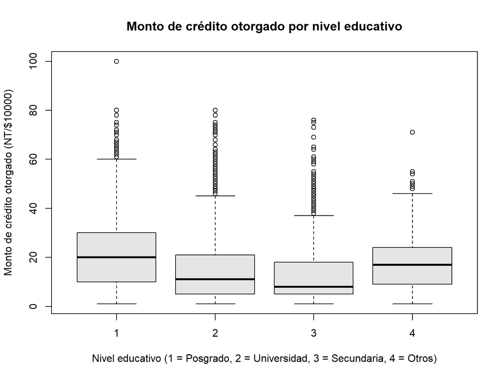

```r
boxplot(LIMIT_BAL/10000 ~ EDUCATION, data = datos_credit_visu, #CHICOS FAVOR MIRAR ESTE K SIGNIFICA 5 Y 6 Y 0 XDDD
        main = "Monto de crédito otorgado por nivel educativo",
        xlab = "Nivel educativo (1 = Posgrado, 2 = Universidad, 3 = Secundaria, 4 = Otros)", ylab = "Monto de crédito otorgado (NT/$10000)",
        col = "grey90")
```

Gráfico con diferencias claras. Medianas: 20 (posgrado), 11 (universidad), 8 (secundaria), 17 (otros). Cajas: 10-30, 5-21, 5-18, 9-24. Hay gradiente descendente 1→2→3: a menor nivel educativo, menor cupo. El grupo 4 se ubica entre 1 y 2. Los bigotes superiores siguen el mismo orden: 60, 45, 37, 46.

Se cruza `AGE` contra `EDUCATION`, para observar cómo se distribuye la edad de los clientes según su nivel educativo.

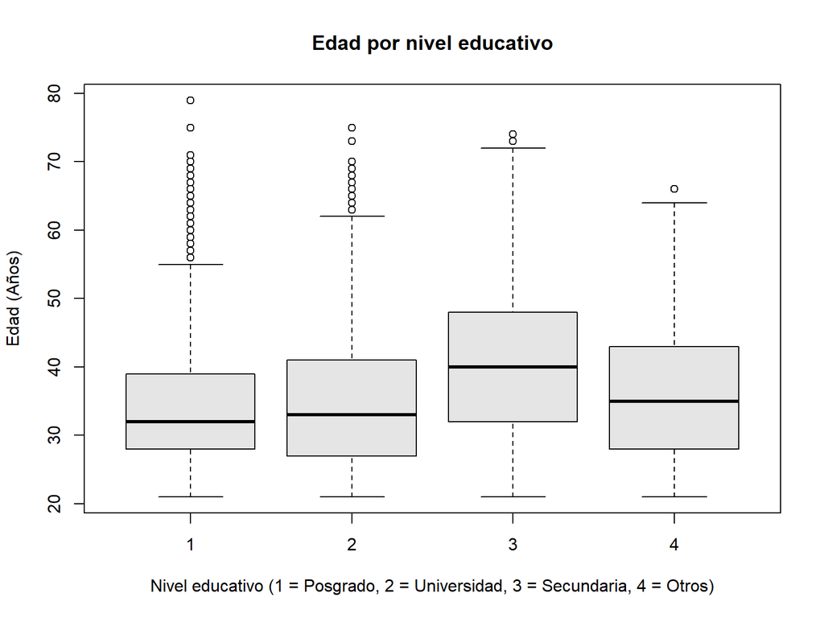

```r
boxplot(AGE ~ EDUCATION, data = datos_credit_visu,
        main = "Edad por nivel educativo",
        xlab = "Nivel educativo (1 = Posgrado, 2 = Universidad, 3 = Secundaria, 4 = Otros)", ylab = "Edad (Años)",
        col = "grey90")
```

Diferencia visible en sentido inverso. Medianas: 32, 33, 40, 35. El grupo 3 es claramente mayor y más disperso (caja 32-48, contra 28-39 en el grupo 1). Ojo: esto se cruza con LIMIT_BAL, el grupo con menor cupo es también el de más edad.

Se cruzan `BILL_AMT1` a `BILL_AMT6` (montos del estado de cuenta de septiembre a abril de 2005) contra `EDUCATION`, generando un boxplot por mes para comparar el monto del estado de cuenta según el nivel educativo del cliente.

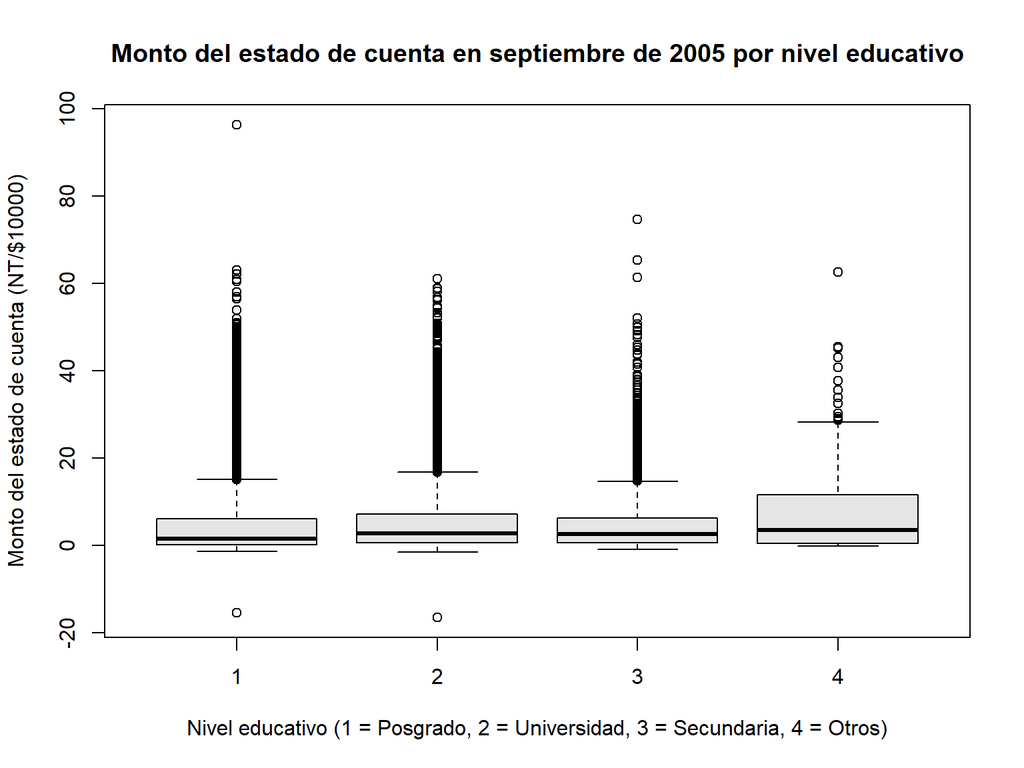

```r
boxplot(BILL_AMT1/10000 ~ EDUCATION, data = datos_credit_visu,
        main = "Monto del estado de cuenta en septiembre de 2005 por nivel educativo",
        xlab = "Nivel educativo (1 = Posgrado, 2 = Universidad, 3 = Secundaria, 4 = Otros)", ylab = "Monto del estado de cuenta (NT/$10000)",
        col = "grey90")
```

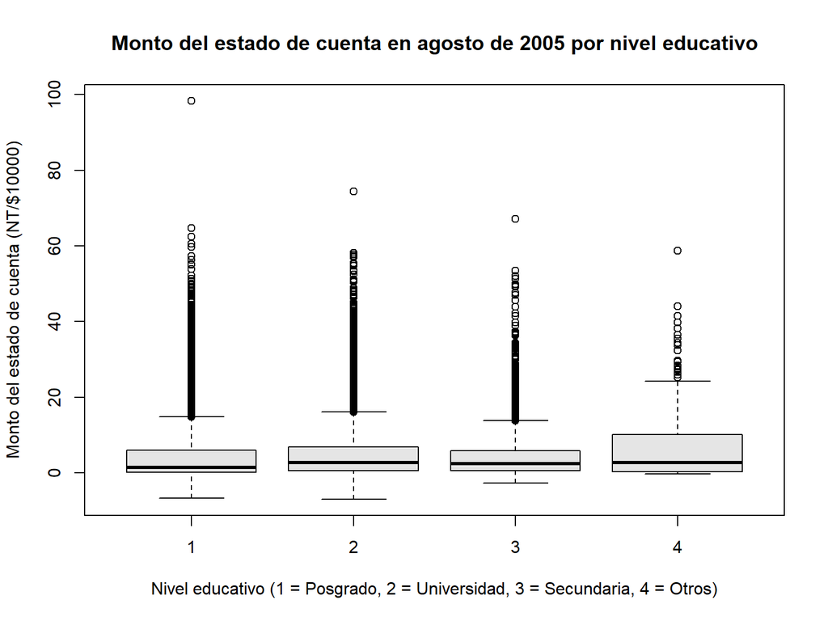

```r
boxplot(BILL_AMT2/10000 ~ EDUCATION, data = datos_credit_visu,
        main = "Monto del estado de cuenta en agosto de 2005 por nivel educativo",
        xlab = "Nivel educativo (1 = Posgrado, 2 = Universidad, 3 = Secundaria, 4 = Otros)", ylab = "Monto del estado de cuenta (NT/$10000)",
        col = "grey90")
```

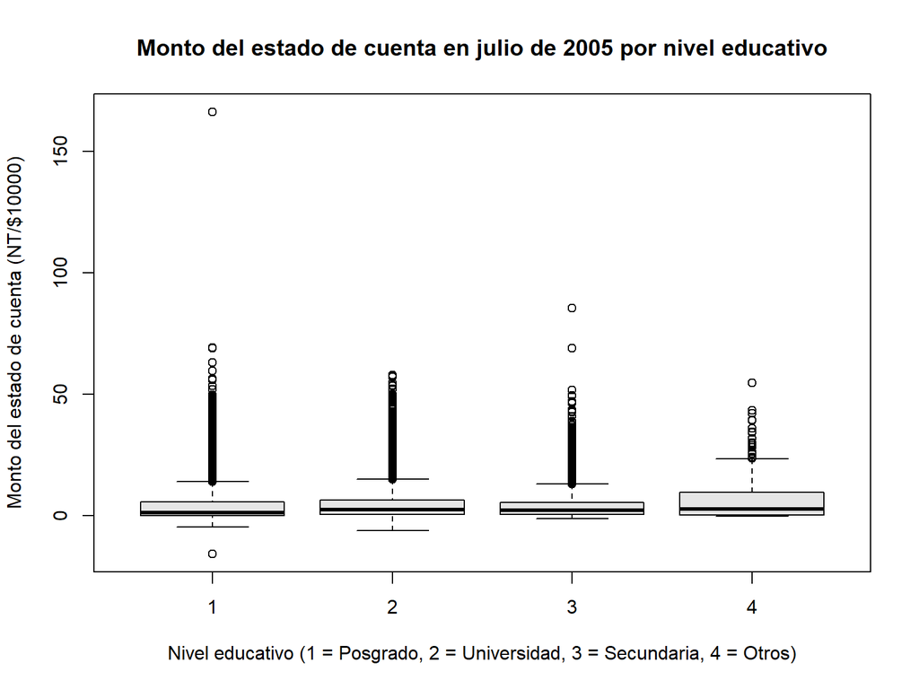

```r
boxplot(BILL_AMT3/10000 ~ EDUCATION, data = datos_credit_visu,
        main = "Monto del estado de cuenta en julio de 2005 por nivel educativo",
        xlab = "Nivel educativo (1 = Posgrado, 2 = Universidad, 3 = Secundaria, 4 = Otros)", ylab = "Monto del estado de cuenta (NT/$10000)",
        col = "grey90")
```

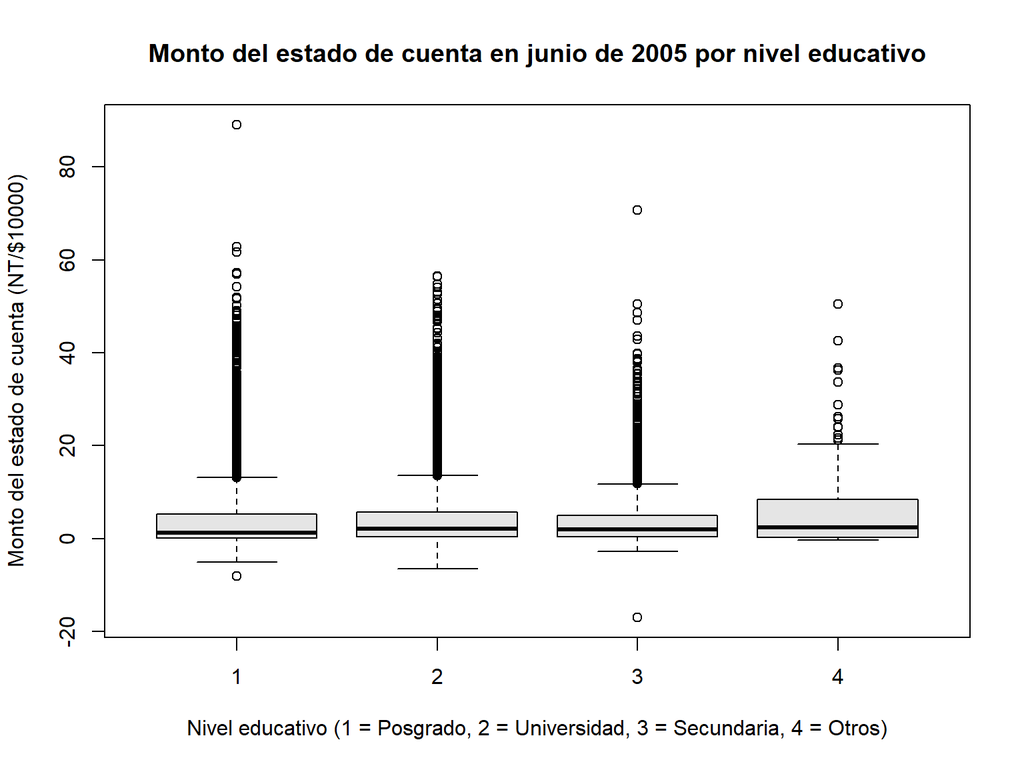

```r
boxplot(BILL_AMT4/10000 ~ EDUCATION, data = datos_credit_visu,
        main = "Monto del estado de cuenta en junio de 2005 por nivel educativo",
        xlab = "Nivel educativo (1 = Posgrado, 2 = Universidad, 3 = Secundaria, 4 = Otros)", ylab = "Monto del estado de cuenta (NT/$10000)",
        col = "grey90")
```

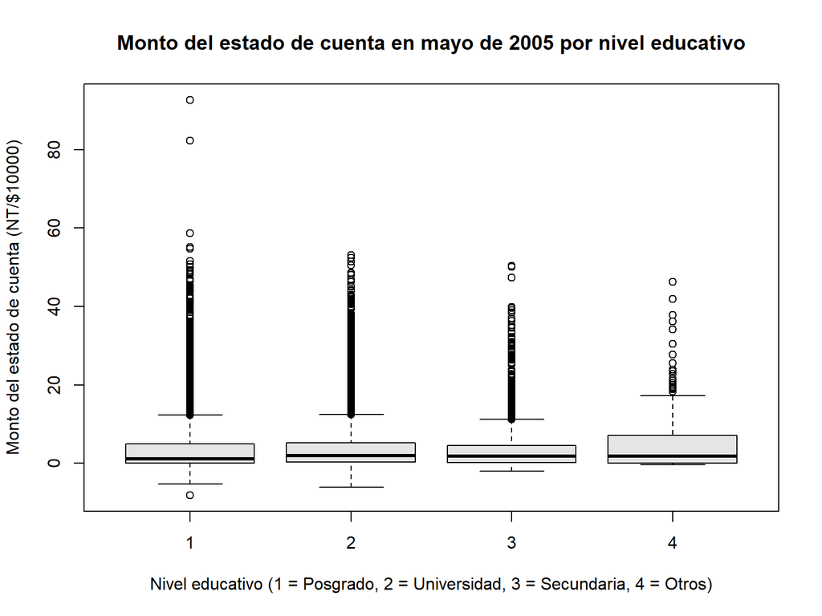

```r
boxplot(BILL_AMT5/10000 ~ EDUCATION, data = datos_credit_visu,
        main = "Monto del estado de cuenta en mayo de 2005 por nivel educativo",
        xlab = "Nivel educativo (1 = Posgrado, 2 = Universidad, 3 = Secundaria, 4 = Otros)", ylab = "Monto del estado de cuenta (NT/$10000)",
        col = "grey90")
```

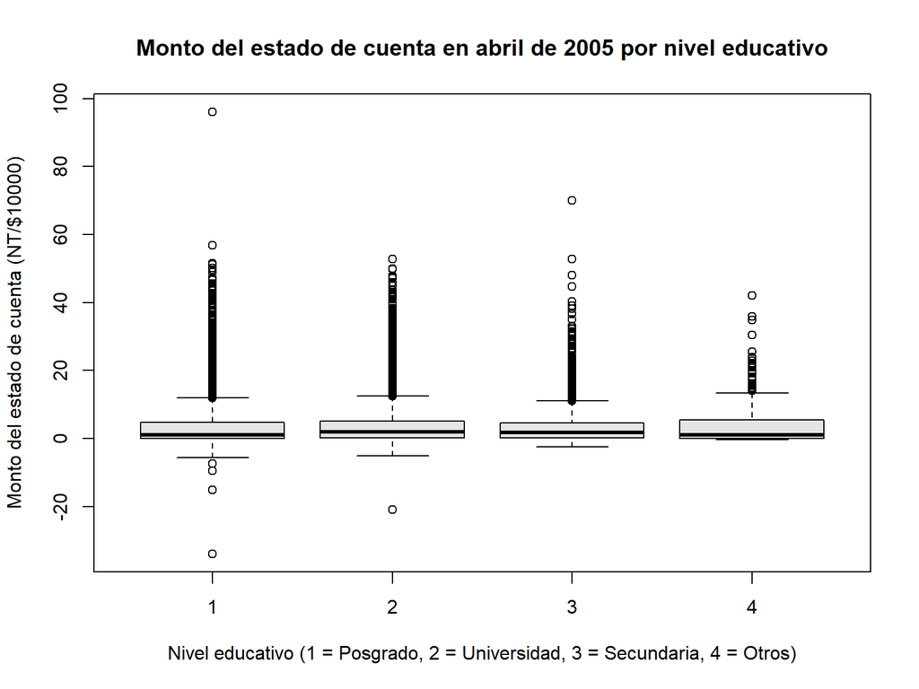

```r
boxplot(BILL_AMT6/10000 ~ EDUCATION, data = datos_credit_visu,
        main = "Monto del estado de cuenta en abril de 2005 por nivel educativo",
        xlab = "Nivel educativo (1 = Posgrado, 2 = Universidad, 3 = Secundaria, 4 = Otros)", ylab = "Monto del estado de cuenta (NT/$10000)",
        col = "grey90")
```